# TP2

Jules Herrmann

15 novembre 2022

## 5) Programmation

### Exercice 1

```r
n<-1
while(sample(0:1,size=1,prob=c(0.3,0.7)) == 0) n<- n+1

print(n)
```

```
## [1] 1
```

Ce code effectue des épreuves de Bernouilli de paramètre $p=0.7$. et compte le nombre d'epreuve à effectuer avant le premier succès. Il modélise donc une variable aléatoire suivant une loi géométrique de paramètre $p=0.7$.

### Exercice 2

#### 1

```r
Geometrique <- function(p){
  n<- 0
  while(sample(0:1,size=1,prob=c(1-p,p)) == 0) n<- n+1
  return(n)
}

Geometrique(0.1)
```

```
## [1] 3
```

#### 2

```r
BinomialNegative <- function(p,k){
  n<-0
  r<-0
  while(n<k){
    r<-r+1
    if (sample(0:1,size=1,prob=c(1-p,p)) == 1){
      n<-n+1
      }
  }
  return(r)
}

BinomialNegative(0.5,5)
```

```
## [1] 7
```

## 6) Loi de probabilité usuelles

### Exercice 3

#### 1

```r
rbinom(n=30,size=1,prob=.2)
```

```
##  [1] 0 0 0 0 0 0 0 0 0 0 0 0 0 0 0 0 0 1 1 0 0 0 0 0 0 0 1 1 1 0
```

Appelons $Z$ la variable aléatoire modélisée par ce code, alors il existe $(X)_{i\in [\![1,30 ]\!}$, 3O variables aléatroires, telles que $Z = \underset{i}{\sum}X_i$.

On a $\forall i, X_i \sim \mathcal{B}(0.2)$ donc $Z$ suit une loi binomiale : $Z\sim\mathcal{B}(30,0.2)$

#### 2

##### 2.1

```r
qgeom(p=.5,prob=.2)
```

```
## [1] 3
```

Cette fonction calcule le quantile de la distribution géométrique de paramètre $p=0.2$.

Soit $X\sim \text{Geom}(p)$, $\mathbb{P}(X=x) = (1-p)^{x-1}p$

Donc
$$d = F_x(x) = \sum_{i=1}^{x-1} (1-p)^i p = p \frac{1-(1-p)^{x-1}}{1-(1-p)}= 1-(1-p)^{x-1}$$
$$\Leftrightarrow \quad 1-d = e^{(x-1) ln(1-p)} \Leftrightarrow x = \left\lceil \frac{ln(1-d)}{ln(1-p)} \right \rceil -1$$
En replacant avec les bonnes valeurs, on a bien
$$\left\lceil \frac{ln(1-0.5)}{ln(1-0.2)} \right \rceil -1 = 3$$

##### 2.2

```r
pbinom(q=7,size=5,prob=.3)
```

```
## [1] 1
```

Or, en 5 tirage, on obtient toujours moins de 7 succès, donc, avec $X \sim \mathcal{B}(5,0.3)$, $\mathbb{P}(X \leq 7) =1$ ce qui correspond à la valeur obtenue avec le code.

## 7) Loi des grands nombres

### Execrice 4

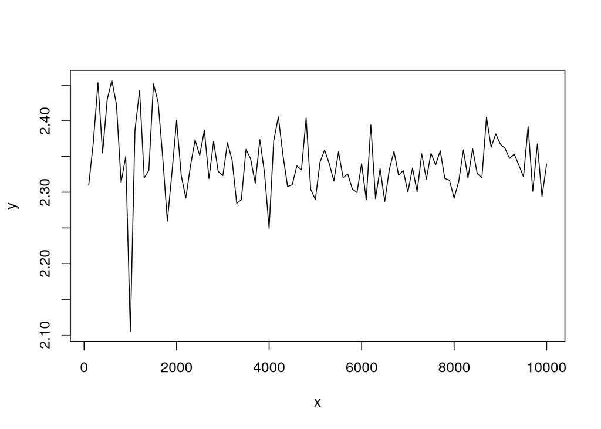

```r
x <- 100*(1:100)
y <- sapply(x,function(x){mean(rgeom(x,0.3))})

plot(x,y,type="l")
```

### Execrice 5

#### 1

```r
monteCarloPi <- function(n){
  4 * sum(runif(n)**2 + runif(n)**2 <=1)/n
}
monteCarloPi(200)
```

```
## [1] 3.16
```

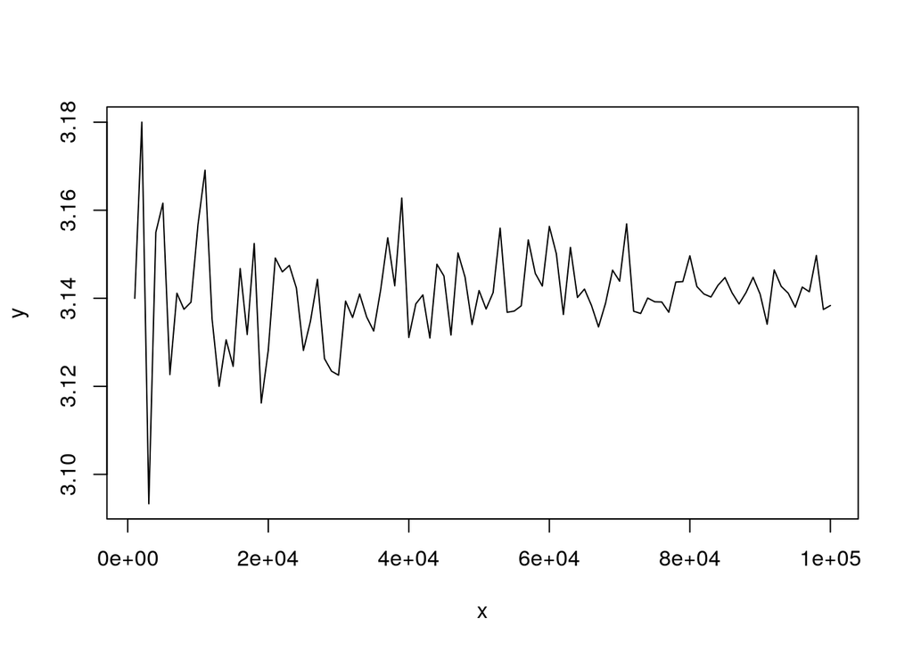

```r
x <- 1000*(1:100)
y <- sapply(x,monteCarloPi)

plot(x,y,type="l")
```

#### 2

```r
monteCarloNormalDist <- function(n){
  sum(abs(rnorm(n))<2)/(n*2)
}
monteCarloNormalDist(200)
```

```
## [1] 0.4725
```

```r
pnorm(2)-pnorm(0)
```

```
## [1] 0.4772499
```

## 8) Exercice de synthèse

### Execrice 6

#### 1

```r
InitPopulation <- function(N){
  rep(1,N)
}
```

#### 2

```r
IterPop <- function(population,N,p){
  population * rbinom(N,size=1,1-p)
}
```

#### 3

```r
EvolPop <- function(N,p,n){
  population <- InitPopulation(N)
  for (i in 1:n){
    population <- IterPop(population,N,p)
  }
  return(population)
}
```

```r
EvolPop(10,0.1,4 )
```

```
##  [1] 1 1 1 1 1 1 0 1 1 0
```

#### 4

```r
Extinct <- function(N,p){
  population <- InitPopulation(N)
  n<-0
  while(sum(population)>0){
    population <- IterPop(population,N,p)
    n<-n+1
  }
  return(n)
}
```

```r
Extinct(10,0.5)
```

```
## [1] 4
```

#### 5

```r
estimation_esperance <- function(N,p,n){
  mean(sapply(1:n, function(x){Extinct(N,p)}))
}
```

```r
estimation_esperance(10,0.3,100)
```

```
## [1] 8.58
```